# An Exploratory Study on What Makes a House a Home

Peter Gray, Ashley King, James Kolesar

May 06 2020

## (a) First candidate model: The model we arrived at in the last project

```r
housing = read_excel("Housing.xlsx")
first.model = lm(log(housing$price) ~ I(housing$bath^3) + housing$lot + housing$garagesize)
summary(first.model)
```

```
##
## Call:
## lm(formula = log(housing$price) ~ I(housing$bath^3) + housing$lot +
##     housing$garagesize)
##
## Residuals:
##      Min       1Q   Median       3Q      Max
## -0.43148 -0.10259 -0.02308  0.13486  0.43122
##
## Coefficients:
##                    Estimate Std. Error t value Pr(>|t|)
## (Intercept)        5.325127   0.075316  70.704  < 2e-16 ***
## I(housing$bath^3)  0.005549   0.002485   2.233  0.02867 *
## housing$lot        0.027401   0.014222   1.927  0.05797 .
## housing$garagesize 0.081207   0.030342   2.676  0.00921 **
## ---
## Signif. codes:  0 '***' 0.001 '**' 0.01 '*' 0.05 '.' 0.1 ' ' 1
##
## Residual standard error: 0.1917 on 72 degrees of freedom
## Multiple R-squared:  0.2245, Adjusted R-squared:  0.1922
## F-statistic: 6.949 on 3 and 72 DF,  p-value: 0.0003583
```

This model certainly isn’t perfect, but it gets the job done in that it takes certain attributes of houses and uses them to predict its price. In terms of flaws, it looks like this model overcomplicates things. We have a great group of variables that should be able to accurately predict price without needing to use transformations. Even beyond that, the transformations that were chosen don’t make all that much sense. Cubing the amount of bathrooms found in a house puts too much weight on that variable, disproportionate to the amount of importance usually placed on it. The number of bathrooms is definitely important, but it could easily be argued that a variable like the size of the house is more universally taken into account when assessing a home’s characteristics. An even more astute argument would be that as the number of bathrooms increases it should have less and less importance to a homeowner. Going from 1 bath to 2 is a pretty big deal, especially for families of 4 or 5, but going from 2 baths to 3 would have less relevance for whether or not to buy a home, so cubing the value is counterintuitive in the sense that larger bathroom quantities shouldn’t have more weight arbitrarily put on them. We’re curious to see the optimized models that R goes with and how they’ll compare to our initial model, not only in accuracy but also in style.

## (b) Second candidate model: Using regsubsets over the entire data set

```r
regfit.housing = regsubsets(price ~ size + lot + bath + bedrooms + agestandardized + garagesize + status + elem, data = housing, nvmax = 18)
reg.summary = summary(regfit.housing)
```

```r
par(mfrow=c(2,2))
plot(reg.summary$rsq,xlab="Number of Variables",ylab="R-squared",type="l")
which.max(reg.summary$rsq)
```

```
## [1] 13
```

```r
plot(reg.summary$adjr2,xlab="Number of Variables",ylab="Adjusted RSq",type="l")
which.max(reg.summary$adjr2)
```

```
## [1] 9
```

```r
points(9,reg.summary$adjr2[9], col="red",cex=2,pch=20)
plot(reg.summary$cp,xlab="Number of Variables",ylab="Cp",type='l')
which.min(reg.summary$cp)
```

```
## [1] 6
```

```r
points(6,reg.summary$cp[6],col="red",cex=2,pch=20)
which.min(reg.summary$bic)
```

```
## [1] 6
```

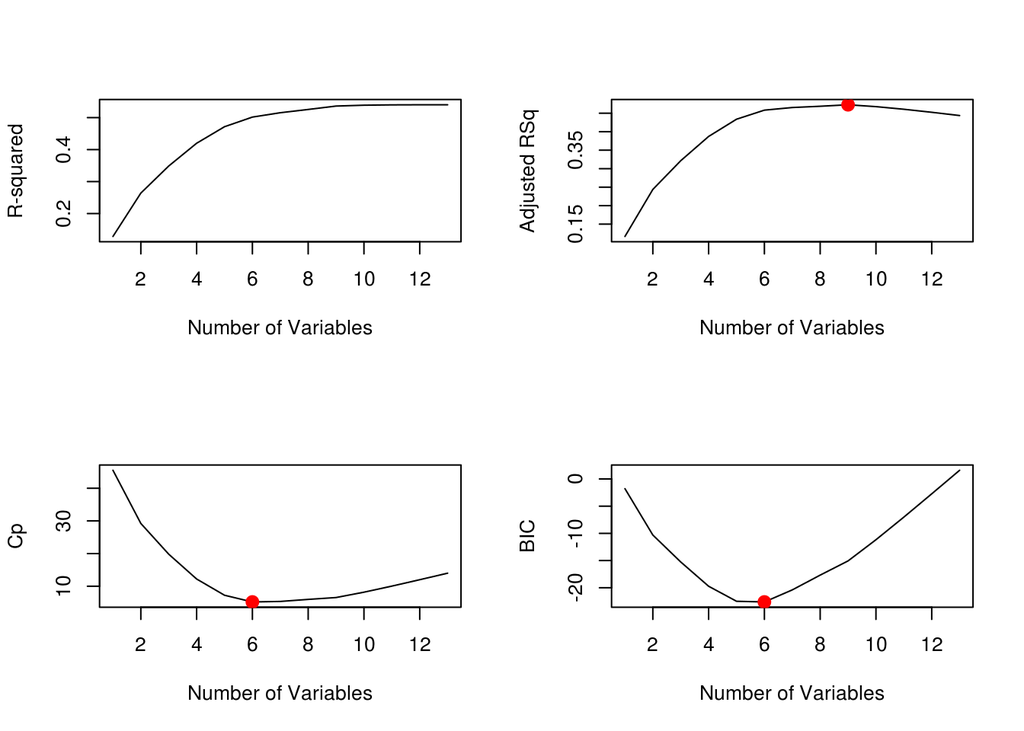

```r
plot(reg.summary$bic,xlab="Number of Variables",ylab="BIC",type='l')
points(6,reg.summary$bic[6],col="red",cex=2,pch=20)
```

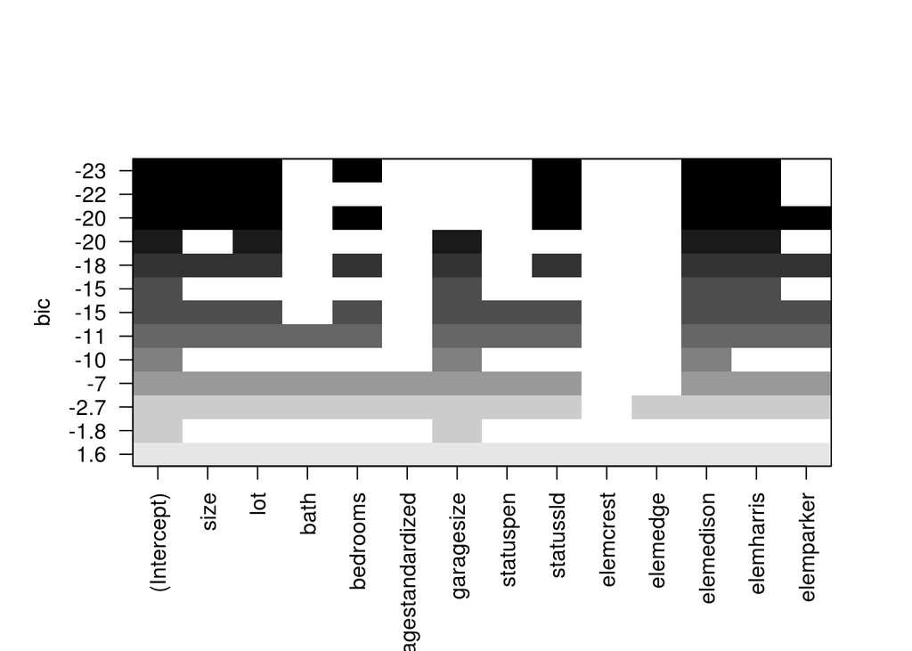

```r
plot(regfit.housing)
```

So there are a few very key things to note here. Firstly, regsubsets is viewing each of the different possible options for our categorical variables as their own unique variable. Creating a linear model including one of our categorical variables does the same thing, dividing it up into different predictors, each with their own coefficient. There’s a bit of a discrepency, however, as regsubsets wants to use only certain aspects of each of our categorical variables and leave the others out, whereas our linear model doesn’t want to separate the different options. In order to combat this, we’ll rework our housing dataset to include a littany of dummy variables instead of just 2 categorical variables:

```r
new.housing = housing
new.housing$statuspen = ifelse(new.housing$status == "pen", 1, 0)
new.housing$statussld = ifelse(new.housing$status == "sld", 1, 0)
new.housing$elemcrest = ifelse(new.housing$elem == "crest", 1, 0)
new.housing$elemedge = ifelse(new.housing$elem == "edge", 1, 0)
new.housing$elemedison = ifelse(new.housing$elem == "edison", 1, 0)
new.housing$elemharris = ifelse(new.housing$elem == "harris", 1, 0)
new.housing$elemparker = ifelse(new.housing$elem == "parker", 1, 0)
new.housing = new.housing[,-10]
new.housing = new.housing[,-10]
```

```r
regfit.new.housing = regsubsets(price ~ size + lot + bath + bedrooms + agestandardized + garagesize + statuspen + statussld + elemcrest + elemedge + elemedison + elemharris + elemparker, data = new.housing, nvmax = 18)
new.reg.summary = summary(regfit.new.housing)
```

```r
par(mfrow=c(2,2))
plot(new.reg.summary$rsq,xlab="Number of Variables",ylab="R-squared",type="l")
which.max(new.reg.summary$rsq)
```

```
## [1] 13
```

```r
plot(new.reg.summary$adjr2,xlab="Number of Variables",ylab="Adjusted RSq",type="l")
which.max(new.reg.summary$adjr2)
```

```
## [1] 9
```

```r
points(9,new.reg.summary$adjr2[9], col="red",cex=2,pch=20)
plot(new.reg.summary$cp,xlab="Number of Variables",ylab="Cp",type='l')
which.min(new.reg.summary$cp)
```

```
## [1] 6
```

```r
points(6,new.reg.summary$cp[6],col="red",cex=2,pch=20)
which.min(new.reg.summary$bic)
```

```
## [1] 6
```

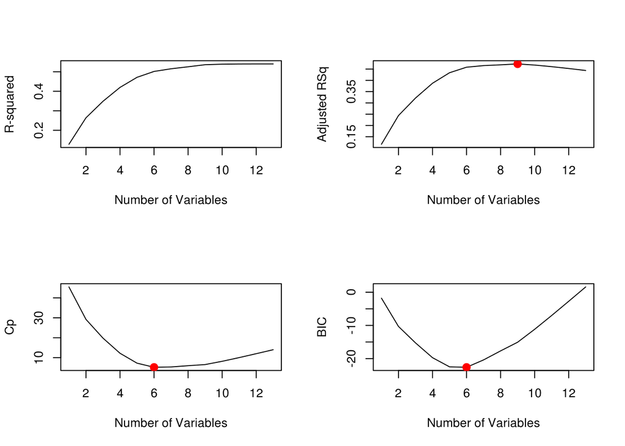

```r
plot(new.reg.summary$bic,xlab="Number of Variables",ylab="BIC",type='l')
points(6,new.reg.summary$bic[6],col="red",cex=2,pch=20)
```

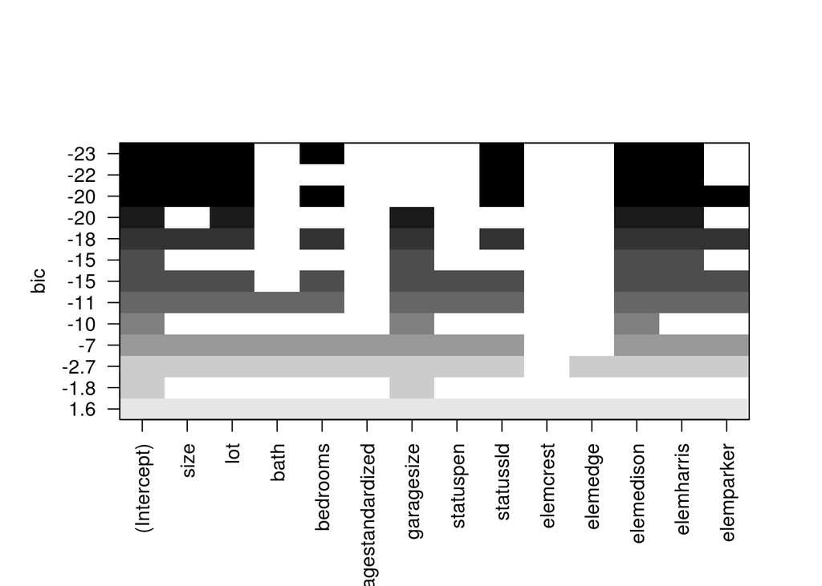

```r
plot(regfit.new.housing)
```

As we can observe, the two give identical results, we just have more to work with when it comes to our new dataset. You’ll notice that statusact and elemadams are both missing from our new.housing data. This is because we’ve filled in all the rest of the blanks, so including them as dummy variables would be rendered obsolete (adding a linear dependency, as r so dutifully noted when we put them into the data originally). R automatically ignored them in its analysis of our first housing dataset, and rightfully so.

The second key thing to note is the number of variables that we should be using. Aside from basic R-squared, any of the other three options are viable, but looking at all three paints a picture that points us to choose 6 as our ideal amount of variables. The biggest factor in the decision comes in the form of the BIC’s sudden increase after 6. BIC penalizes its score for each variable you add, so at a certain point that penalty starts to outweigh what your variable brings to the table as a predictor. The starkness of this increase indicates that these variables really don’t add too much to our model, something also displayed by the marginal increases from 6 to 9 in our Adjusted R-Squared plot. Anywhere from 6 to 9 would work, and when in doubt, simpler is better.

```r
coef(regfit.housing, 6)
```

```
## (Intercept)        size         lot    bedrooms   statussld  elemedison
##  127.556047   85.475310    9.995031  -16.004639  -34.907872   79.665432
##  elemharris
##   54.392695
```

```r
coef(regfit.new.housing, 6)
```

```
## (Intercept)        size         lot    bedrooms   statussld  elemedison
##  127.556047   85.475310    9.995031  -16.004639  -34.907872   79.665432
##  elemharris
##   54.392695
```

Since our dataset isn’t massive, it doesn’t look like we’ll have to worry about optimizing computing power, so overall selection gives us the best possible model at every amount of variables. Showing the model from both the modified and original dataset once again confirms that the two are identical, giving identical results, and we can now move forward with creating our linear model unhindered by our elementary school districts or status of the home on the market being tied together under one variable.

```r
second.model = lm(price ~ size + lot + bedrooms + statussld + elemedison + elemharris, data = new.housing)
summary(second.model)
```

```
##
## Call:
## lm(formula = price ~ size + lot + bedrooms + statussld + elemedison +
##     elemharris, data = new.housing)
##
## Residuals:
##     Min      1Q  Median      3Q     Max
## -101.09  -31.98   -0.27   28.20  116.16
##
## Coefficients:
##             Estimate Std. Error t value Pr(>|t|)
## (Intercept)  127.556     52.793   2.416 0.018336 *
## size          85.475     25.412   3.364 0.001259 **
## lot            9.995      3.426   2.918 0.004756 **
## bedrooms     -16.005      7.839  -2.042 0.045021 *
## statussld    -34.908     10.823  -3.225 0.001925 **
## elemedison    79.665     14.674   5.429 7.94e-07 ***
## elemharris    54.393     14.720   3.695 0.000436 ***
## ---
## Signif. codes:  0 '***' 0.001 '**' 0.01 '*' 0.05 '.' 0.1 ' ' 1
##
## Residual standard error: 44.41 on 69 degrees of freedom
## Multiple R-squared:  0.5016, Adjusted R-squared:  0.4583
## F-statistic: 11.57 on 6 and 69 DF,  p-value: 6.344e-09
```

## (c) Creating a training/test split using half of the data

```r
length(new.housing$id)
```

```
## [1] 76
```

```r
set.seed(111)
training.numbers = sample(76,38)
new.housing.training = new.housing[training.numbers,]
new.housing.test = new.housing[-training.numbers,]
```

## (d) Third candidate model: Using regsubsets over the training data, then the entire data set

```r
regfit.new.housing.training = regsubsets(price ~ size + lot + bath + bedrooms + agestandardized + garagesize + statuspen + statussld + elemcrest + elemedge + elemedison + elemharris + elemparker, data = new.housing.training, nvmax = 14)
new.reg.training.summary = summary(regfit.new.housing.training)
```

```r
par(mfrow=c(2,2))
plot(new.reg.training.summary$rsq,xlab="Number of Variables",ylab="R-squared",type="l")
which.max(new.reg.training.summary$rsq)
```

```
## [1] 13
```

```r
plot(new.reg.training.summary$adjr2,xlab="Number of Variables",ylab="Adjusted RSq",type="l")
which.max(new.reg.training.summary$adjr2)
```

```
## [1] 7
```

```r
points(7,new.reg.training.summary$adjr2[7], col="red",cex=2,pch=20)
plot(new.reg.training.summary$cp,xlab="Number of Variables",ylab="Cp",type='l')
which.min(new.reg.training.summary$cp)
```

```
## [1] 5
```

```r
points(5,new.reg.training.summary$cp[5],col="red",cex=2,pch=20)
which.min(new.reg.training.summary$bic)
```

```
## [1] 3
```

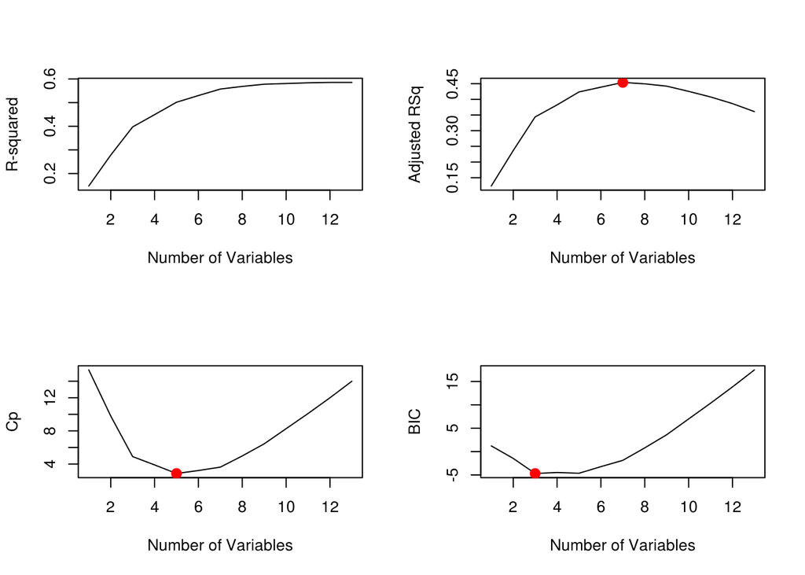

```r
plot(new.reg.training.summary$bic,xlab="Number of Variables",ylab="BIC",type='l')
points(3,new.reg.training.summary$bic[3],col="red",cex=2,pch=20)
```

Again, we think that there is much to be gleamed from looking at all three possible methods of model selection. This time it looks like 5 is that breakpoint where BIC begins to really rise and the increases in Adjusted R-Squared become less consequential. What was 6-9 has become 5-7, and again, the simpler the better.

```r
coef(regfit.new.housing.training, 5)
```

```
## (Intercept)        size         lot   statussld  elemedison  elemharris
##    40.00518    95.48676    13.52832   -39.57955    71.08112    65.65588
```

```r
coef(regfit.new.housing, 5)
```

```
## (Intercept)        size         lot   statussld  elemedison  elemharris
##    91.58663    71.86498    12.02793   -38.73841    79.35125    62.39044
```

Somewhat reassuringly, our 5 variable model for our training data uses the same predictors as our model for the entire dataset.

```r
third.model = lm(price ~ size + lot + statussld + elemedison + elemharris, data = new.housing)
summary(third.model)
```

```
##
## Call:
## lm(formula = price ~ size + lot + statussld + elemedison + elemharris,
##     data = new.housing)
##
## Residuals:
##     Min      1Q  Median      3Q     Max
## -95.626 -33.643  -2.306  37.115 110.050
##
## Coefficients:
##             Estimate Std. Error t value Pr(>|t|)
## (Intercept)   91.587     50.880   1.800 0.076161 .
## size          71.865     25.070   2.867 0.005477 **
## lot           12.028      3.351   3.589 0.000611 ***
## statussld    -38.738     10.898  -3.555 0.000683 ***
## elemedison    79.351     15.001   5.290 1.33e-06 ***
## elemharris    62.390     14.506   4.301 5.41e-05 ***
## ---
## Signif. codes:  0 '***' 0.001 '**' 0.01 '*' 0.05 '.' 0.1 ' ' 1
##
## Residual standard error: 45.4 on 70 degrees of freedom
## Multiple R-squared:  0.4715, Adjusted R-squared:  0.4338
## F-statistic: 12.49 on 5 and 70 DF,  p-value: 1.127e-08
```

## (e) Fourth candidate model: Using ridge regression

```r
x.training = model.matrix(price ~ size + lot + bath + bedrooms + yearbuilt + agestandardized + garagesize + statuspen + statussld + elemcrest + elemedge + elemedison + elemharris + elemparker, new.housing.training)[,-1]
y.training = new.housing.training$price
x.test = model.matrix(price ~ size + lot + bath + bedrooms + yearbuilt + agestandardized + garagesize + statuspen + statussld + elemcrest + elemedge + elemedison + elemharris + elemparker, new.housing.test)[,-1]
y.test = new.housing.test$price
```

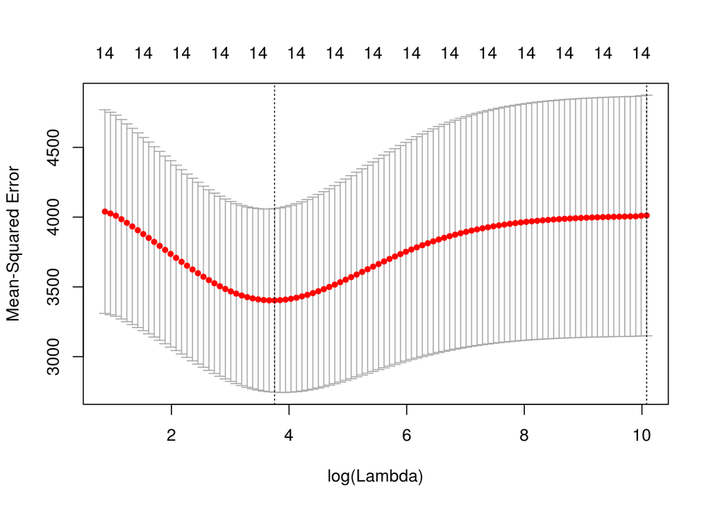

```r
set.seed(111)
cv.out = cv.glmnet(x.training, y.training, alpha=0)
plot(cv.out)
```

```r
bestlam = cv.out$lambda.min
bestlam
```

```
## [1] 42.68726
```

```r
fourth.model = glmnet(x.training, y.training, alpha = 0, lambda = bestlam, thresh=1e-12)
```

Pretty standard ridge regression model creation. The one thing to note would be our ignoring the ID variable in our dataset, since it shouldn’t be considered as a predictor in any case.

## (f) Fifth candidate model: Using principal components regression

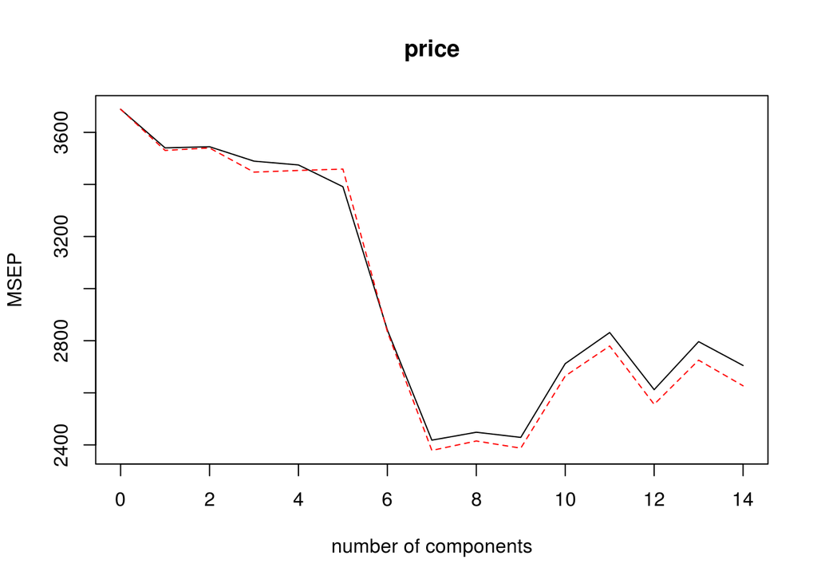

```r
set.seed(111)
fifth.model = pcr(price ~ size + lot + bath + bedrooms + yearbuilt + agestandardized + garagesize + statuspen + statussld + elemcrest + elemedge + elemedison + elemharris + elemparker, data = new.housing, scale = TRUE, validation = "CV")

validationplot(fifth.model, val.type = "MSEP")
```

Again, our plot gives us a range of values to choose for our number of variables, this time from 7 to 9. Simplest is best, so we’ll pick 7.

## (g) Comparing our mean squared errors and evaluating our models

```r
mean((new.housing$price-predict(first.model, new.housing))[-training.numbers]^2)
```

```
## [1] 80779.25
```

```r
mean((new.housing$price-predict(second.model, new.housing))[-training.numbers]^2)
```

```
## [1] 1586.93
```

```r
mean((new.housing$price-predict(third.model, new.housing))[-training.numbers]^2)
```

```
## [1] 1828.757
```

```r
fourth.model.prediction = predict(fourth.model, s = bestlam, newx = x.test)
mean((fourth.model.prediction - y.test)^2)
```

```
## [1] 1909.236
```

```r
fifth.model.prediction = predict(fifth.model, x.test, ncomp = 7)
mean((fifth.model.prediction-y.test)^2)
```

```
## [1] 1413.446
```

Taking a look at our mean squared error when trying to predict our test data really shines a light on just how flawed our first model wound up being, not only intuitively but also in its accuracy. The MSE for our initial model is just over 50 times the MSE for the regsubset model with 6 variables.